# Proteomic analysis SMEG

Marie Locard-Paulet

Mon Nov 13 15:43:21 2017

# Data input

**There are rows with no values in the abundance.**

```r
input <- read.table("RAW/Proline/Quantified proteins_09-11-2017_1057.txt", header = T, sep = "\t")
mapping <- read.table("RAW/Quantified proteins 290917_Mapping.txt", header = T, sep = "\t")
mapping$Label <- paste0(mapping$cellular.compartment, "-", mapping$biological.replicate, "-", mapping$technical.replicate)
kable(mapping)
```

| Sample.name | cellular.compartment | biological.replicate | technical.replicate | Label |
| --- | --- | --- | --- | --- |
| CF1_1 | secretome | 1 | 1 | secretome-1-1 |
| CF1_2 | secretome | 1 | 2 | secretome-1-2 |
| CF1_3 | secretome | 1 | 3 | secretome-1-3 |
| CF1_4 | secretome | 1 | 4 | secretome-1-4 |
| CF2_1 | secretome | 2 | 1 | secretome-2-1 |
| CF2_2 | secretome | 2 | 2 | secretome-2-2 |
| CF2_3 | secretome | 2 | 3 | secretome-2-3 |
| CF2_4 | secretome | 2 | 4 | secretome-2-4 |
| CF3_1 | secretome | 3 | 1 | secretome-3-1 |
| CF3_2 | secretome | 3 | 2 | secretome-3-2 |
| CF3_3 | secretome | 3 | 3 | secretome-3-3 |
| CF3_4 | secretome | 3 | 4 | secretome-3-4 |
| CF4_1 | secretome | 4 | 1 | secretome-4-1 |
| CF4_2 | secretome | 4 | 2 | secretome-4-2 |
| CF4_3 | secretome | 4 | 3 | secretome-4-3 |
| CF4_4 | secretome | 4 | 4 | secretome-4-4 |
| CP1_1 | cytoplasm | 1 | 1 | cytoplasm-1-1 |
| CP1_2 | cytoplasm | 1 | 2 | cytoplasm-1-2 |
| CP1_3 | cytoplasm | 1 | 3 | cytoplasm-1-3 |
| CP1_4 | cytoplasm | 1 | 4 | cytoplasm-1-4 |
| CP2_1 | cytoplasm | 2 | 1 | cytoplasm-2-1 |
| CP2_2 | cytoplasm | 2 | 2 | cytoplasm-2-2 |
| CP2_3 | cytoplasm | 2 | 3 | cytoplasm-2-3 |
| CP2_4 | cytoplasm | 2 | 4 | cytoplasm-2-4 |
| CP3_1 | cytoplasm | 3 | 1 | cytoplasm-3-1 |
| CP3_2 | cytoplasm | 3 | 2 | cytoplasm-3-2 |
| CP3_3 | cytoplasm | 3 | 3 | cytoplasm-3-3 |
| CP3_4 | cytoplasm | 3 | 4 | cytoplasm-3-4 |
| CP4_1 | cytoplasm | 4 | 1 | cytoplasm-4-1 |
| CP4_2 | cytoplasm | 4 | 2 | cytoplasm-4-2 |
| CP4_3 | cytoplasm | 4 | 3 | cytoplasm-4-3 |
| CP4_4 | cytoplasm | 4 | 4 | cytoplasm-4-4 |
| CW1_1 | mycomembrane | 1 | 1 | mycomembrane-1-1 |
| CW1_2 | mycomembrane | 1 | 2 | mycomembrane-1-2 |
| CW1_3 | mycomembrane | 1 | 3 | mycomembrane-1-3 |
| CW1_4 | mycomembrane | 1 | 4 | mycomembrane-1-4 |
| CW2_1 | mycomembrane | 2 | 1 | mycomembrane-2-1 |
| CW2_2 | mycomembrane | 2 | 2 | mycomembrane-2-2 |
| CW2_3 | mycomembrane | 2 | 3 | mycomembrane-2-3 |
| CW2_4 | mycomembrane | 2 | 4 | mycomembrane-2-4 |
| CW3_1 | mycomembrane | 3 | 1 | mycomembrane-3-1 |
| CW3_2 | mycomembrane | 3 | 2 | mycomembrane-3-2 |
| CW3_3 | mycomembrane | 3 | 3 | mycomembrane-3-3 |
| CW3_4 | mycomembrane | 3 | 4 | mycomembrane-3-4 |
| CW4_1 | mycomembrane | 4 | 1 | mycomembrane-4-1 |
| CW4_2 | mycomembrane | 4 | 2 | mycomembrane-4-2 |
| CW4_3 | mycomembrane | 4 | 3 | mycomembrane-4-3 |
| CW4_4 | mycomembrane | 4 | 4 | mycomembrane-4-4 |
| MP1_1 | plasma membrane | 1 | 1 | plasma membrane-1-1 |
| MP1_2 | plasma membrane | 1 | 2 | plasma membrane-1-2 |
| MP1_3 | plasma membrane | 1 | 3 | plasma membrane-1-3 |
| MP1_4 | plasma membrane | 1 | 4 | plasma membrane-1-4 |
| MP2_1 | plasma membrane | 2 | 1 | plasma membrane-2-1 |
| MP2_2 | plasma membrane | 2 | 2 | plasma membrane-2-2 |
| MP2_3 | plasma membrane | 2 | 3 | plasma membrane-2-3 |
| MP2_4 | plasma membrane | 2 | 4 | plasma membrane-2-4 |
| MP3_1 | plasma membrane | 3 | 1 | plasma membrane-3-1 |
| MP3_2 | plasma membrane | 3 | 2 | plasma membrane-3-2 |
| MP3_3 | plasma membrane | 3 | 3 | plasma membrane-3-3 |
| MP3_4 | plasma membrane | 3 | 4 | plasma membrane-3-4 |
| MP4_1 | plasma membrane | 4 | 1 | plasma membrane-4-1 |
| MP4_2 | plasma membrane | 4 | 2 | plasma membrane-4-2 |
| MP4_3 | plasma membrane | 4 | 3 | plasma membrane-4-3 |
| MP4_4 | plasma membrane | 4 | 4 | plasma membrane-4-4 |

I keep the columns “abundance” from the Proline table.

# Data cleaning

I do not remove the abundance values when no “psm_count”. We want to analyse the results filtered by David’s algo.

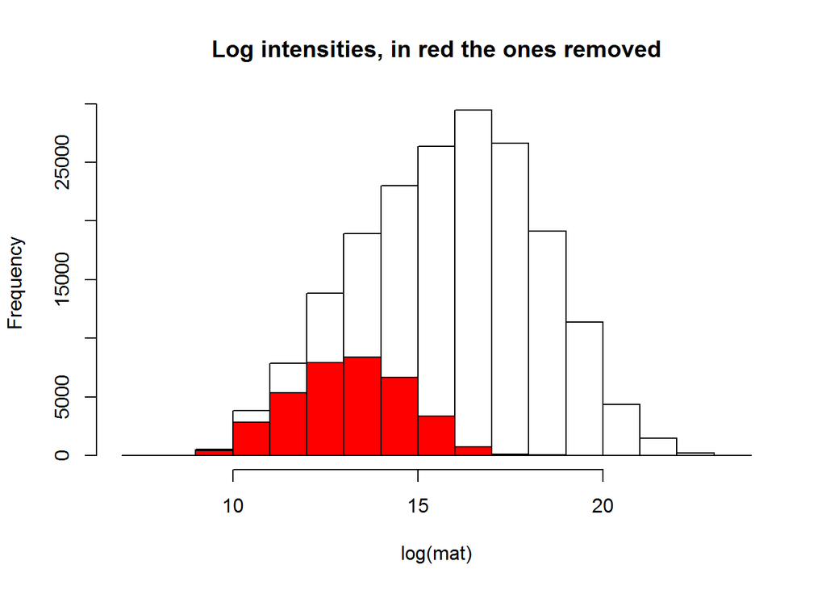

There are 127830 values with NAs or 0 psm_count.

# Quality control

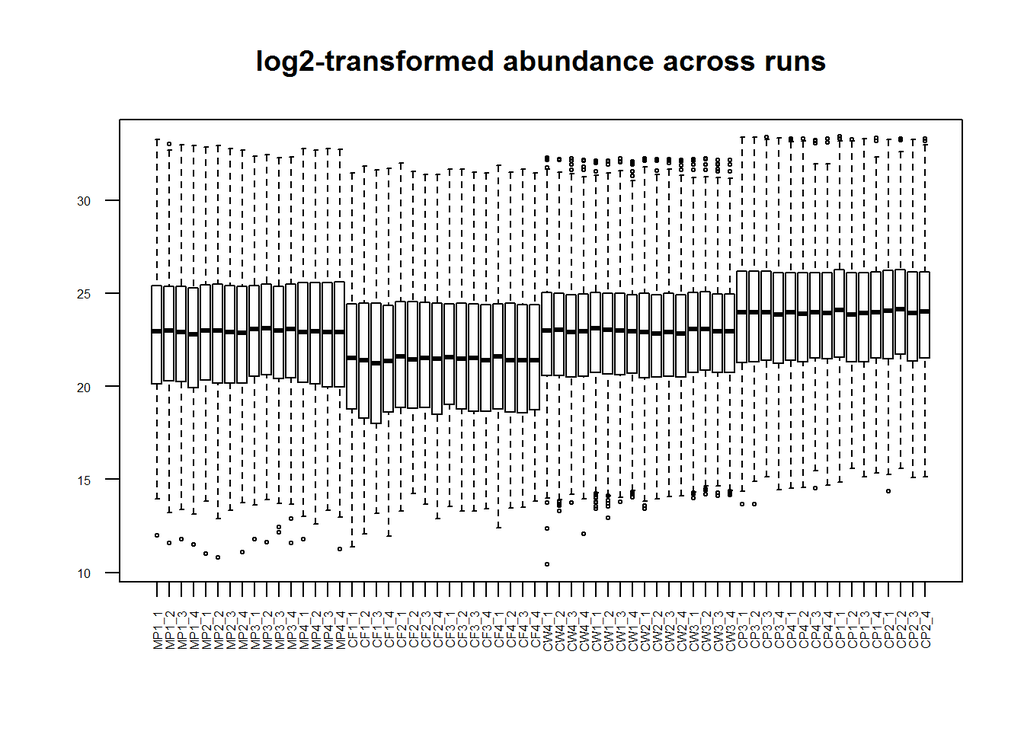

*The normalisation has been performed by compartment, which explains the difference observed between the medians of each group.*

# Data centering

Normalisation of the samples using the median (on the log-2 transformed data).

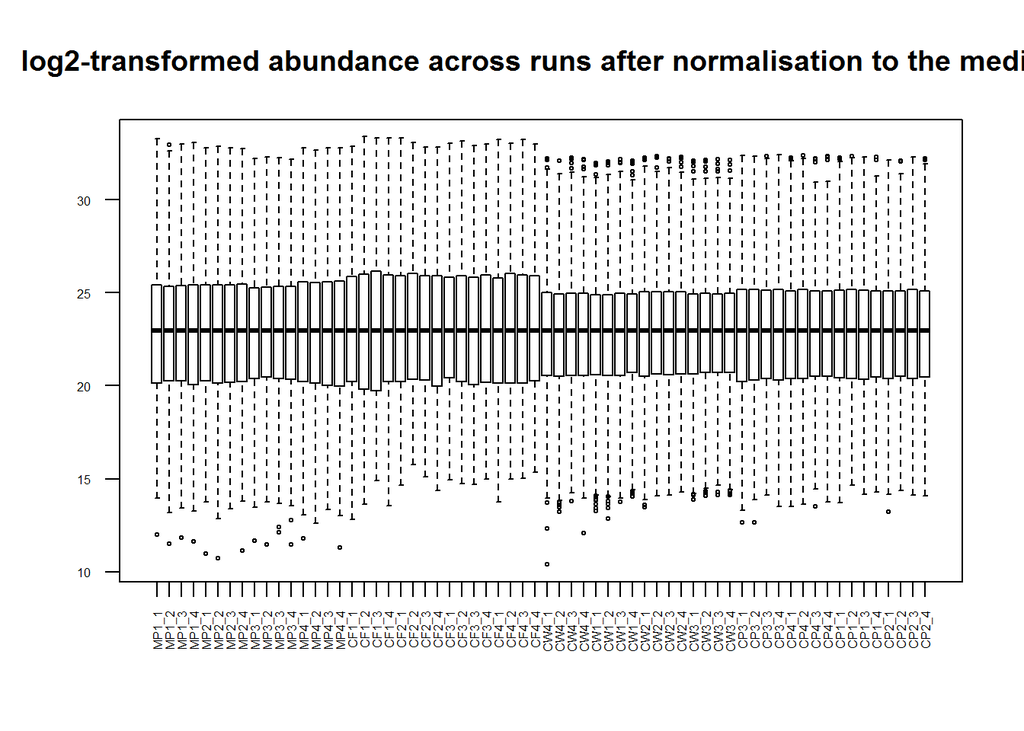

## Correlation analysis on the data with no missing values

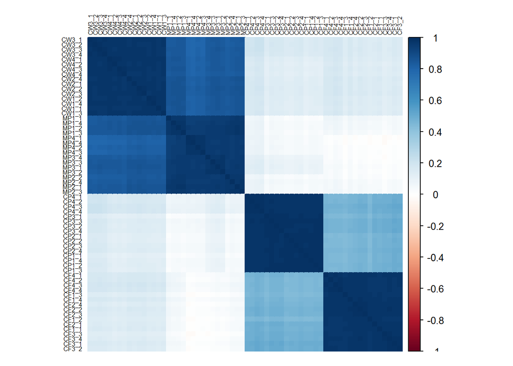

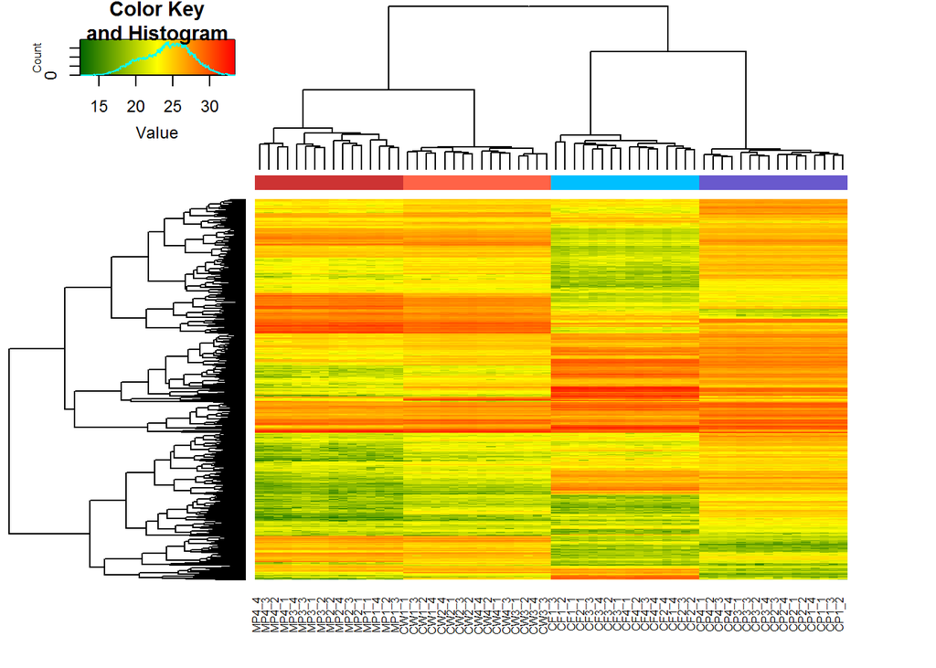

## PCA analysis on the data with no missing values

I center the data.

|  | PC1 | PC2 | PC3 |
| --- | --- | --- | --- |
| Standard deviation | 17.97669 | 15.88692 | 8.943297 |
| Proportion of Variance | 0.46524 | 0.36336 | 0.115150 |
| Cumulative Proportion | 0.46524 | 0.82860 | 0.943750 |

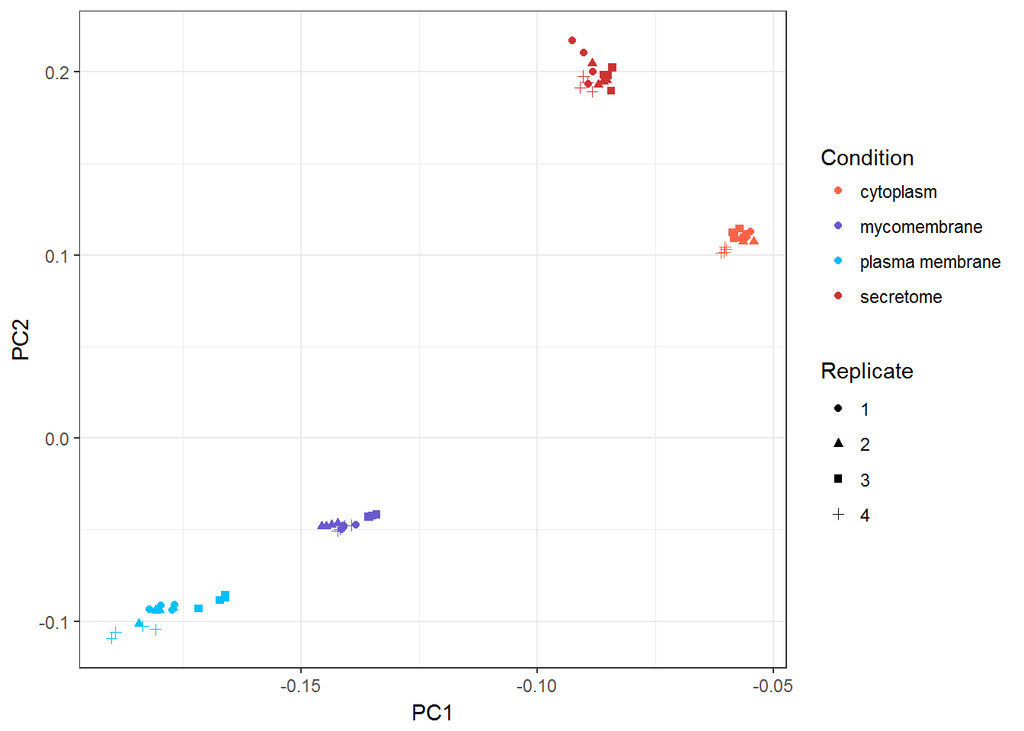

# Identities of the proteins detected in the cell compartments

Proteins are detected in a compartment if these have a detected abundance in a minimum of one biological replicate.

Venn diagrams:

| Cellular.compartment | Number.of.proteins.detected |
| --- | --- |
| cytoplasm | 3308 |
| mycomembrane | 3371 |
| plasma membrane | 3085 |
| secretome | 2227 |

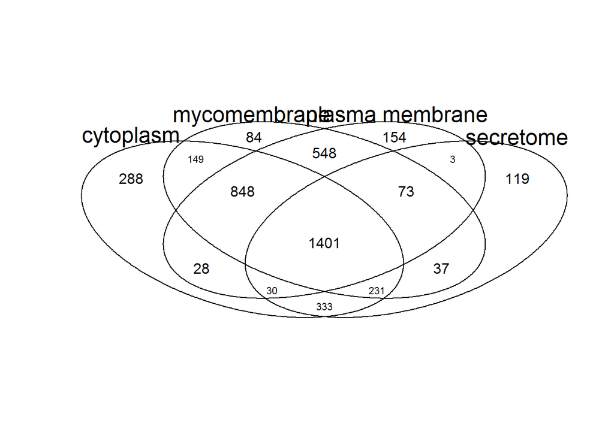

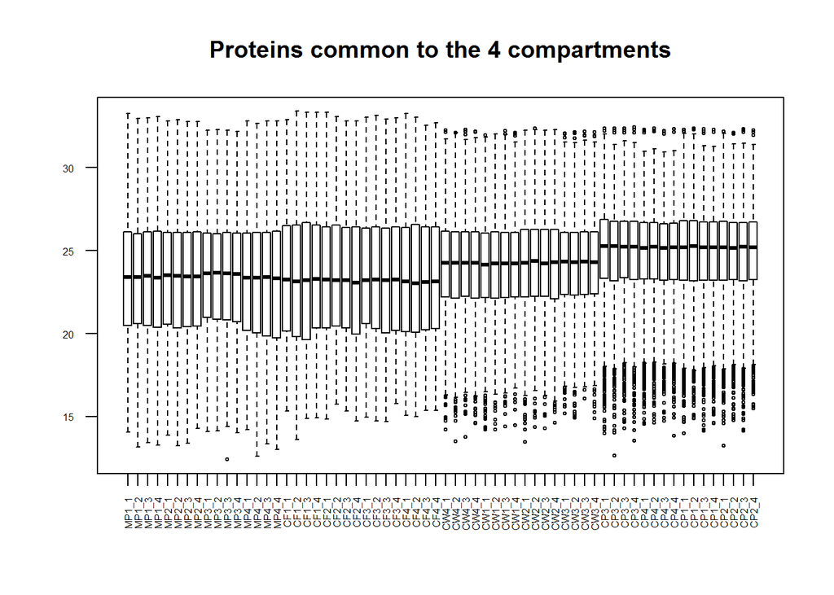

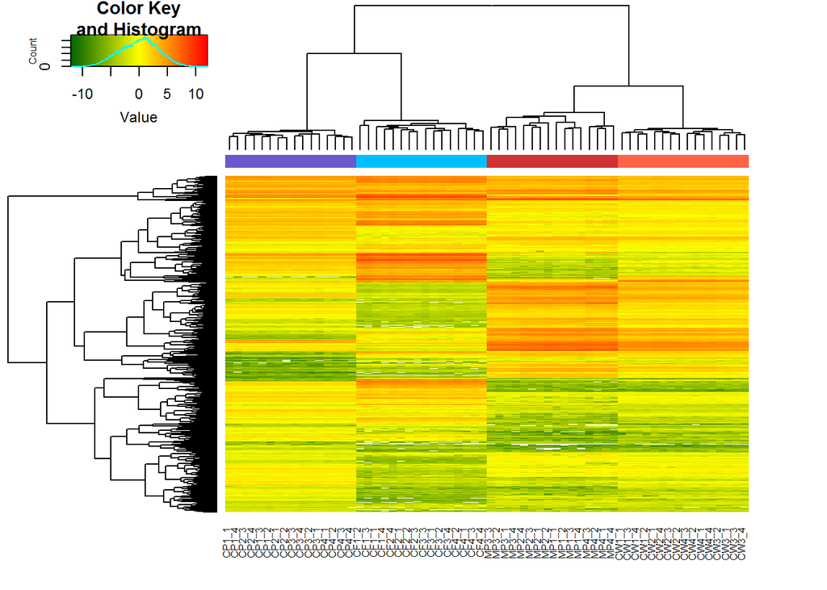

The lists of proteins identified in the compartments are saved in “Output/Proline/”

# Data export

I export the data in “Data"

```r
save(list = c("input", "mat", "mapping", "matcol", "matRaw"), file = "Data/Proline/Data00.Rdata")
```